## Course: VISUAL ANALYTICS FOR POLICY AND MANAGEMENT

### Prof. José Manuel Magallanes, PhD

- Visiting Professor of Computational Policy at Evans School of Public Policy and Governance, and eScience Institute Senior Data Science Fellow, University of Washington.
- Professor of Government and Political Methodology, Pontificia Universidad Católica del Perú.

# Session 4: Tabular data: Univariate Numerical

1. Counting
2. Measuring

**Exercises**:

- Exercise 6
- Exercise 7

Let’s load the data we used for the last session:

```r
link='https://github.com/EvansDataScience/VisualAnalytics_2_tabularData/raw/master/data/eduwa.rda'

#getting the data TABLE from the file in the cloud:
load(file=url(link))
```

## Data from Counting

Counting expresses numerical values. They could be represented with bar plots if their frequency table had few different values, but that is not the case. For example, the variable *Reduced.Lunch* informs how many kids there are in each school that have that lunch for a reduced price. We have more than 2000 schools, so it is possible to have that many different values. This is how many different values we have:

```r
# how many unique values
length(unique(eduwa$Reduced.Lunch))
```

```
## [1] 172
```

There are too many different values. Then, the bar plot is not a good idea (and neither a frequency table):

```r
# barplot without ggplot
library(questionr)
NumDf=freq(eduwa$Reduced.Lunch)

NumDf=data.frame(variable=as.numeric(row.names(NumDf)),
                 NumDf,
                 row.names = NULL)
```

Using the function **freq** from **questionr** we built a frequency table in less steps:

```r
#resultado
head(NumDf)
```

```
##   variable   n   X. val.
## 1        0 368 15.2 16.0
## 2        3 156  6.4  6.8
## 3        4  29  1.2  1.3
## 4        5  37  1.5  1.6
## 5        6  29  1.2  1.3
## 6        7  25  1.0  1.1
```

This ‘bad’ frequeny table will give you a bad barplot:

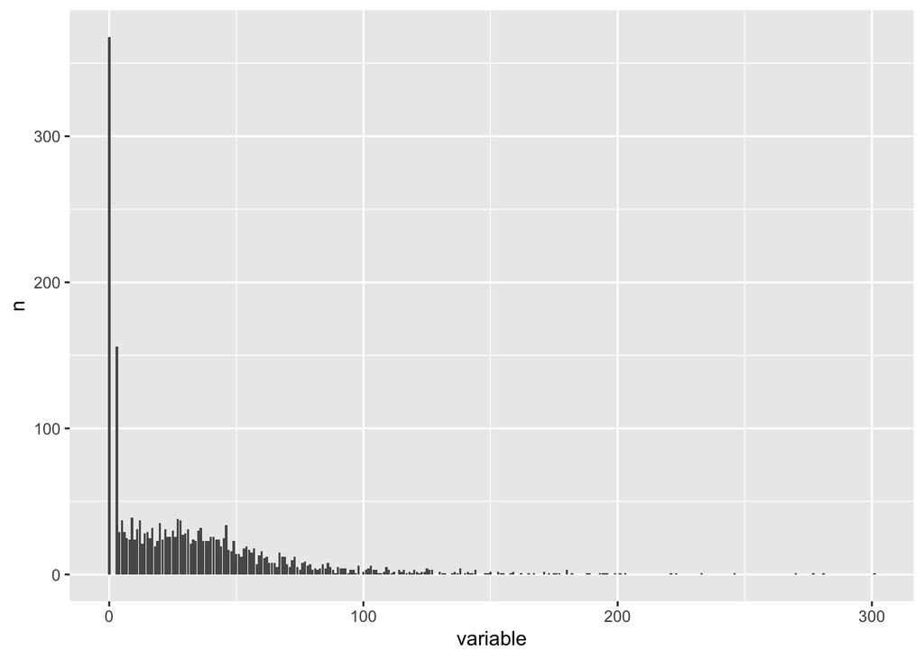

```r
library(ggplot2)
base = ggplot(data=NumDf,aes(x=variable,y=n))
base + geom_bar(stat='identity')
```

The bar plot produces a bar for each unique value in the data, counting how many times this value appeared. Now, we have many values, so we need to organize the data into *intervals*. However, when you have a numerical variable you should keep in mind:

- What is the representative value? Generally the mean, and median in the presence of outliers.
- Does the shape of the distribution differs from a normal distribution?
  - How well is the representative value? You need some measure of dispersion. For the mean you have the **standard deviation**, and for the median the **median absolute deviation**. You can also compute a measure of kurtosis.
  - If there is asymmetry, is it big enough to show outliers? The boxplot will help you identify outliers, but you can compute a measure of asymetry.

You can get several info from this command:

```r
summary(eduwa$Reduced.Lunch)
```

```
##    Min. 1st Qu.  Median    Mean 3rd Qu.    Max.    NA's
##    0.00    5.00   25.50   33.53   47.00  301.00     131
```

The **summary** command can be suplemented with:

```r
# standard deviation:
sd(eduwa$Reduced.Lunch,na.rm = T)
```

```
## [1] 36.55684
```

```r
# median absolute deviation:
mad(eduwa$Reduced.Lunch,na.rm = T)
```

```
## [1] 30.3933
```

```r
# asymmetry
library(DescTools)
Skew(eduwa$Reduced.Lunch,na.rm = T,conf.level = 0.95, ci.type = "bca",R=3000)
```

```
##     skew   lwr.ci   upr.ci
## 2.158124 1.899821 2.494523
```

```r
# shape
#library(DescTools)
Kurt(eduwa$Reduced.Lunch,na.rm = T,conf.level = 0.95, ci.type = "bca",R=3000)
```

```
##      kurt    lwr.ci    upr.ci
##  7.311024  5.309591 10.098018
```

With the values computed, can you guess how a histogram or a boxplot would look?

The **histogram** is the basic plot, you can use the basic function:

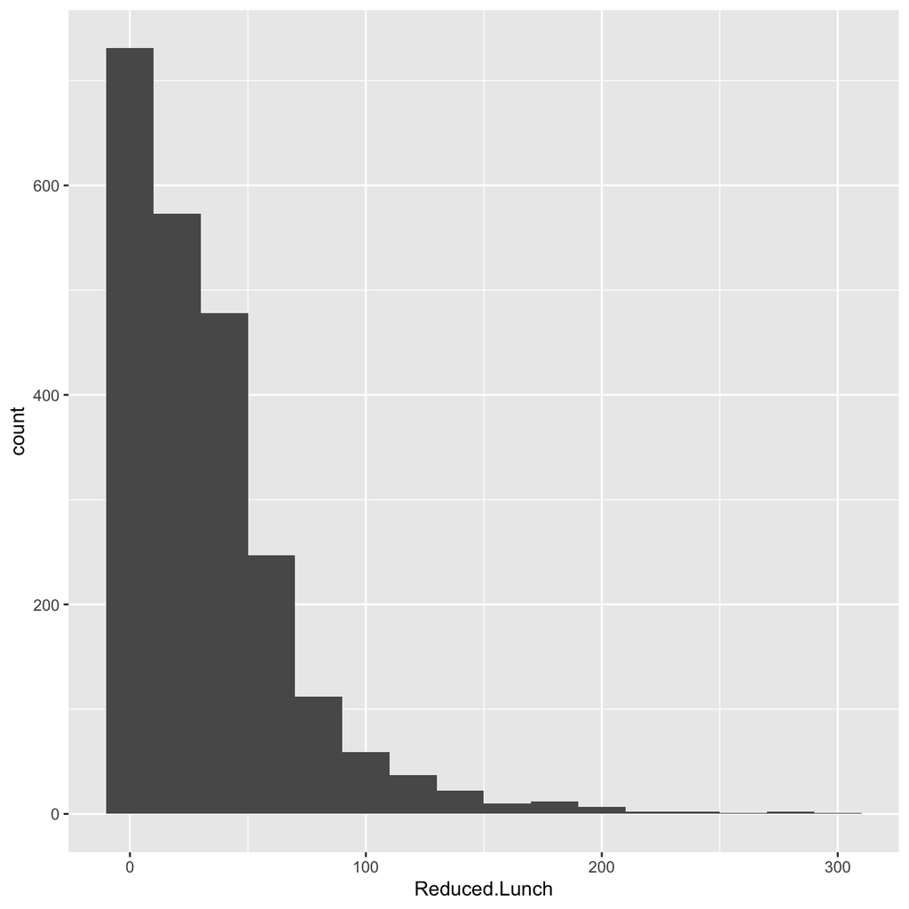

```r
#ggplot
base= ggplot(eduwa,aes(x = Reduced.Lunch))
h1= base + geom_histogram(binwidth = 20)
h1
```

One of the central measures could be used as a reference:

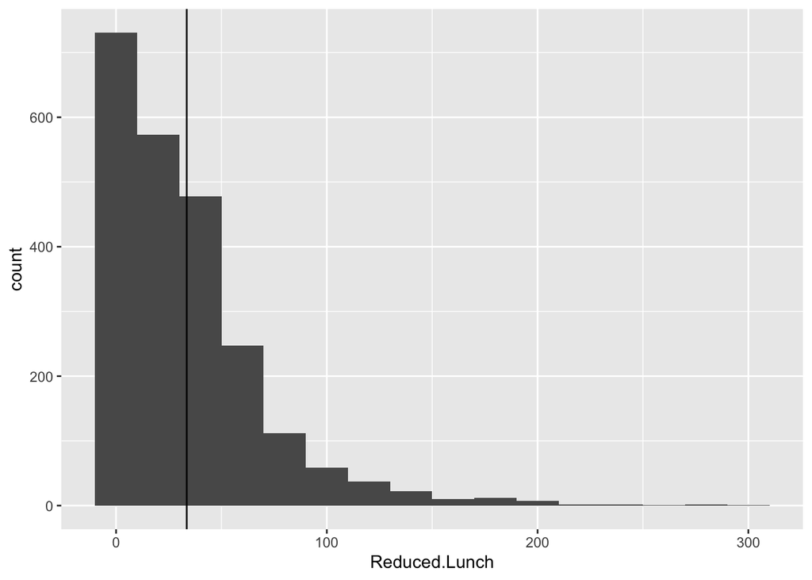

```r
MEAN=summary(eduwa$Reduced.Lunch)[4]
h1+ geom_vline(xintercept = MEAN)
```

The boxplot can also be used:

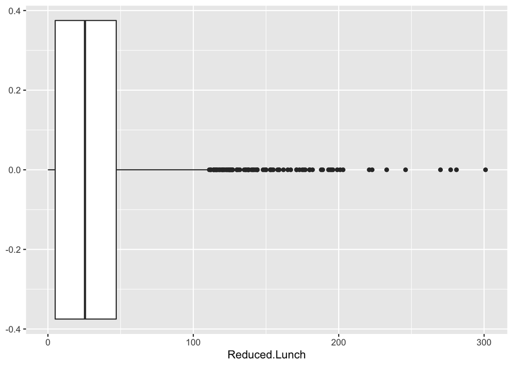

```r
base= ggplot(eduwa,aes(y = Reduced.Lunch))
b1= base + geom_boxplot()
b1 +coord_flip()
```

This boxplot shows outliers, which have been computed using the interquartile range:

```r
# difference between q3 and q1:
theIQR=IQR(eduwa$Reduced.Lunch,na.rm = T)
```

Then you simply add to the top and bottom quartile the IQR multiply by a factor (typically 1.5) to get the outlier threshold:

```r
(upperT=summary(eduwa$Reduced.Lunch)[[5]] + theIQR*1.5)
```

```
## [1] 110
```

Then, we have this many outliers:

```r
sum(eduwa$Reduced.Lunch>upperT,na.rm = T)
```

```
## [1] 96
```

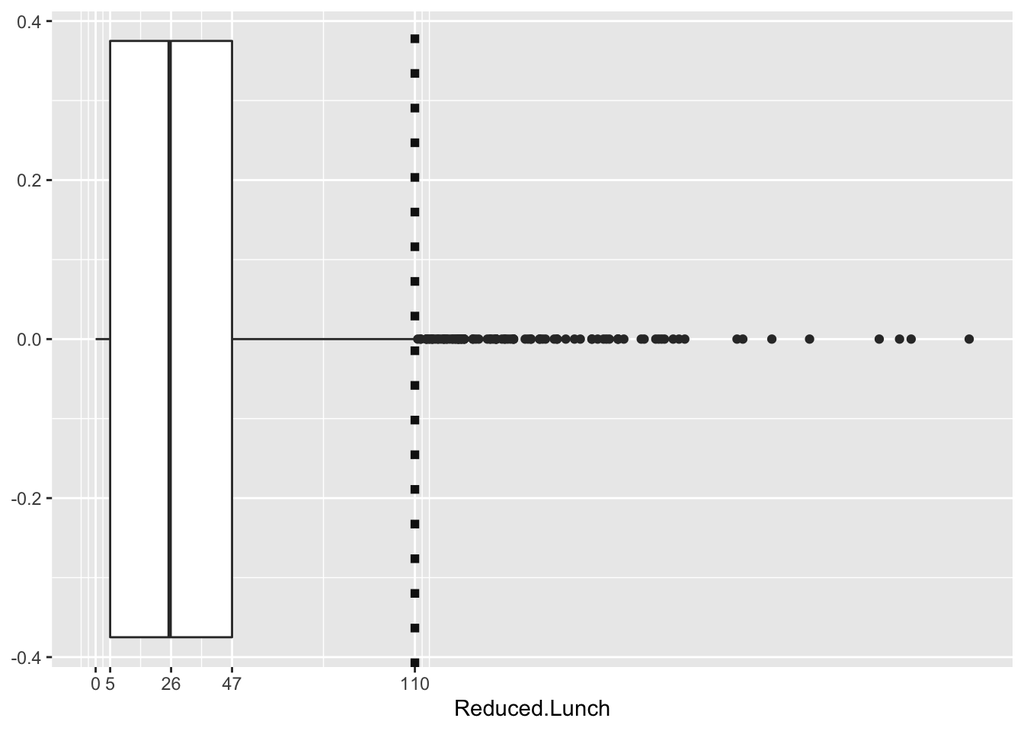

```r
someValues=as.vector(summary(eduwa$Reduced.Lunch)[-c(4,6,7)])
theTicks = round(c(someValues,upperT),0)
b2 = b1 +coord_flip()
b3 = b2 + geom_hline(yintercept = upperT,
                color='grey8',linetype="dotted", size=2)
b3 + scale_y_continuous(breaks = theTicks)
```

In general, measurements and counts are prone to have outliers. It is not common to speak about outliers in ordinal data since they have few levels. From what I just said, the subjective side of finding outliers lies in the decision of **what is normal**. In the case of the boxplot, the decision has been to accept as normal the values that have a *prudent distance* from the first or last quartile. The distance chosen was 1.5 times the difference between the quartiles (a.k.a. Interquartle Range or **IQR**). Then, if a outlier is found, the whisker ends in a position different than the actual minimum or maximal value of the data.

Go to table of contents.

### Measurement

A simplistic idea of measurement tells you the times a particular unit is present in the unit of analysis; which allows for the presence of decimal places. There are variables that can have negative values.

Let’s analyze the variable *Student.Teacher.Ratio*:

```r
summary(eduwa$Student.Teacher.Ratio)
```

```
##    Min. 1st Qu.  Median    Mean 3rd Qu.    Max.    NA's
##    0.10   16.20   18.30   18.95   20.20  330.00     329
```

The histogram should be:

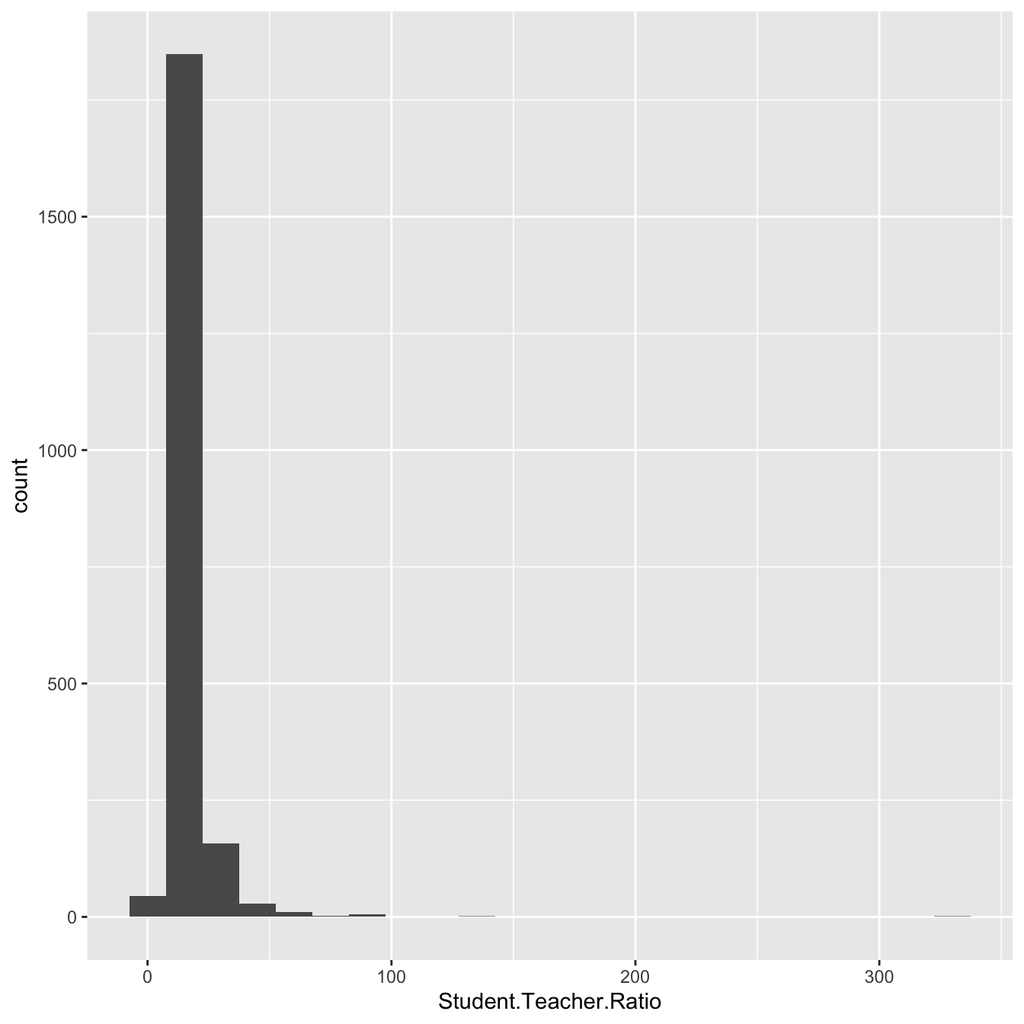

```r
#ggplot
base= ggplot(eduwa,aes(x = Student.Teacher.Ratio))
h1= base + geom_histogram(binwidth = 15) #changing width

h1
```

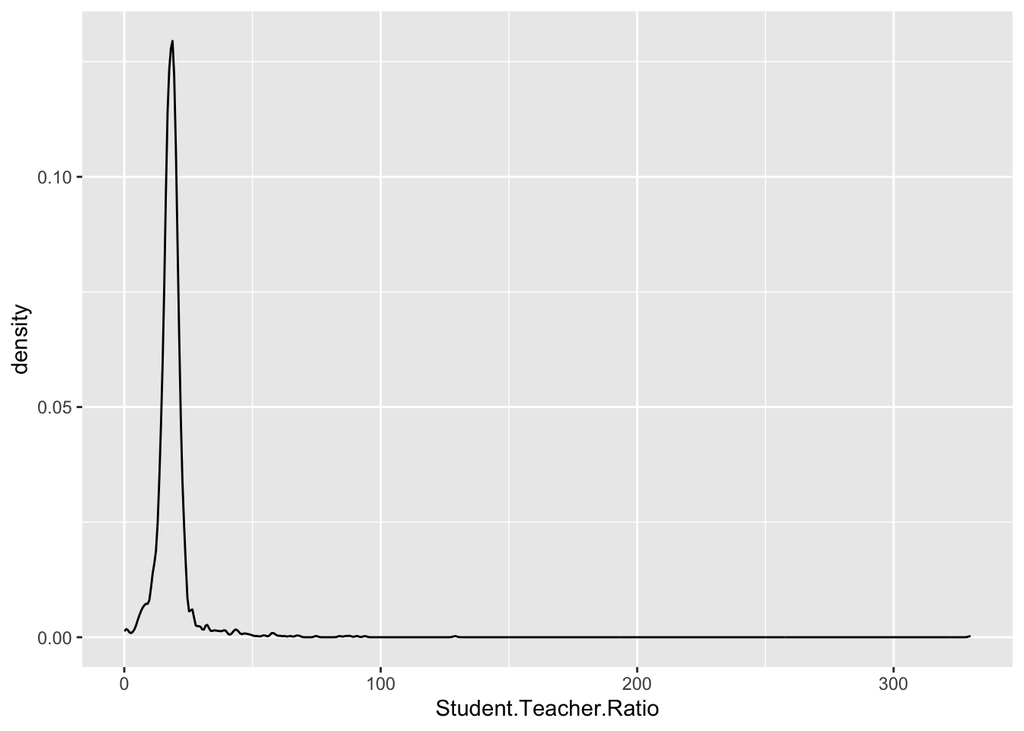

```r
d1= base + stat_density(geom = "line")
d1
```

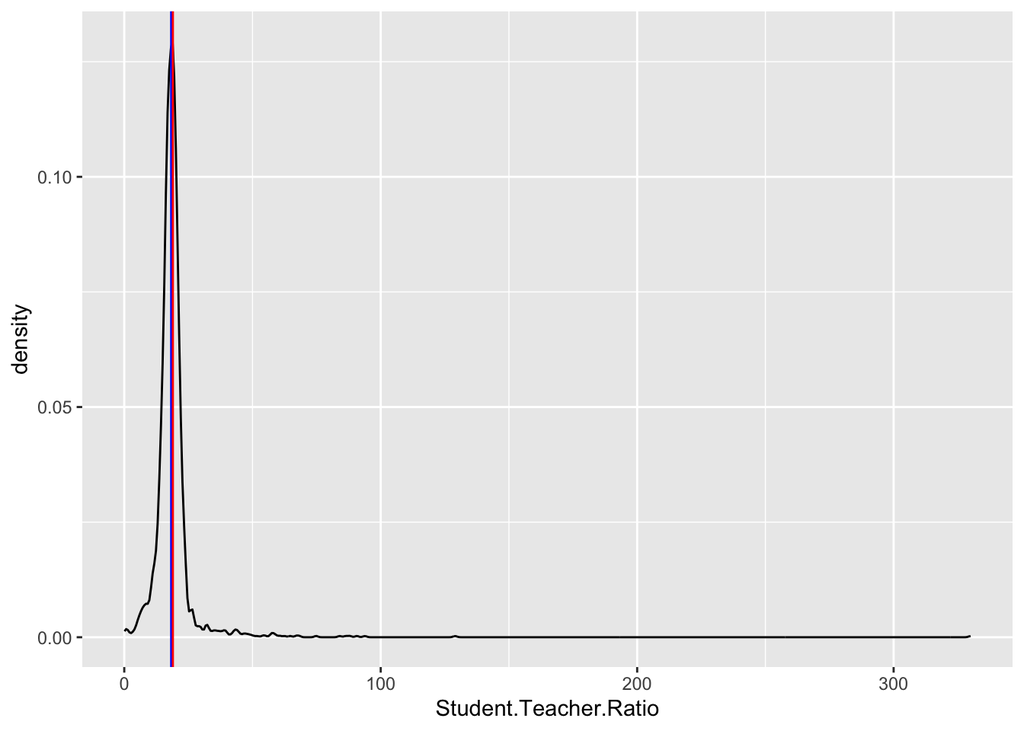

```r
theMean=mean(eduwa$Student.Teacher.Ratio, na.rm = T)
theMedian=median(eduwa$Student.Teacher.Ratio, na.rm = T)

d1 + geom_vline(xintercept = theMedian,color='blue') +
     geom_vline(xintercept =theMean,color='red')
```

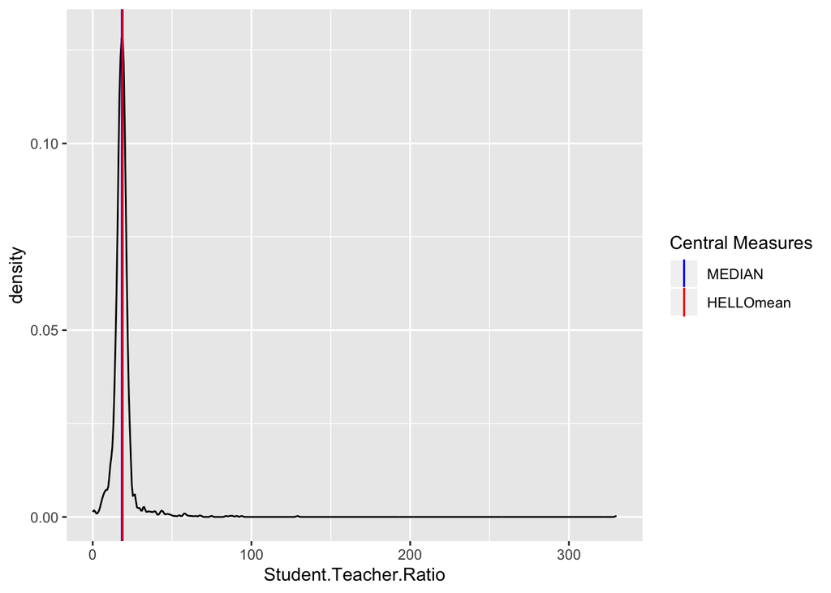

```r
d1 + geom_vline(aes(xintercept = theMedian,color='median')) +
     geom_vline(aes(xintercept =theMean,color='mean')) +
     scale_color_manual(name = "Central Measures",
                        values = c(median = "blue", mean = "red"),
                        breaks = c('median','mean'),
                       labels=c("MEDIAN", "HELLOmean"))
```

A box plot is always welcome:

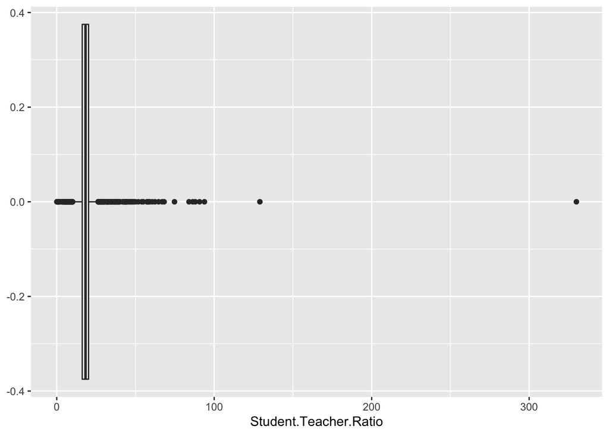

```r
base= ggplot(eduwa,aes(y = Student.Teacher.Ratio))
b1= base + geom_boxplot()

b1 + coord_flip()
```

The presence of outliers suggests different statistical populations:

- The “normal” schools.
- The schools below the “normal”.
- The schools above the “normal”.

```r
# variable of interest
theVAR=eduwa$Student.Teacher.Ratio
# interquartile range
theIQR=IQR(theVAR,na.rm = T)

#thresholds
upperT=summary(theVAR)[[5]] + theIQR*1.5
lowerT=summary(theVAR)[[2]] - theIQR*1.5

# dataframes of subpopulations
belows=eduwa[which(theVAR < lowerT),]
normals=eduwa[which(theVAR >=lowerT & theVAR <= upperT),]
aboves=eduwa[which(theVAR > upperT),]
```

```r
#ggplot
base= ggplot(belows,aes(x = Student.Teacher.Ratio))
d1B= base + stat_density(geom = "line") + labs(title = 'belows')

base= ggplot(normals,aes(x = Student.Teacher.Ratio))
d1N= base + stat_density(geom = "line") + labs(title = 'normals',
                                               y=NULL)

base= ggplot(aboves,aes(x = Student.Teacher.Ratio))
d1A= base + stat_density(geom = "line") + labs(title = 'aboves',
                                               y=NULL)
```

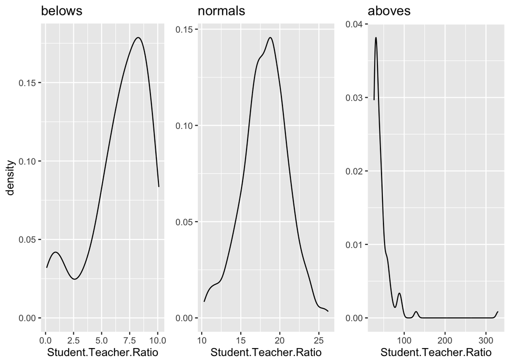

```r
library(ggpubr)
multid1_a = ggarrange(d1B,d1N,d1A,ncol = 3,nrow = 1)
multid1_a
```

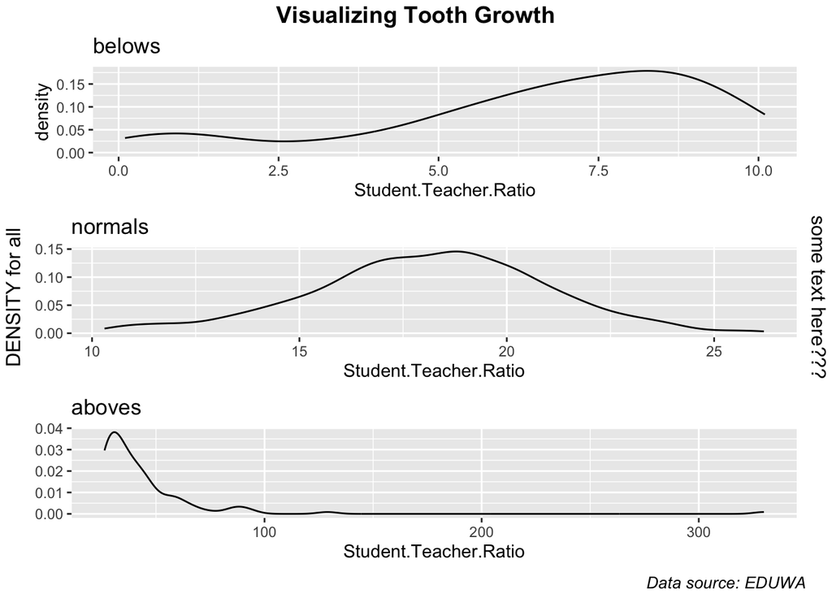

```r
multid1_b = ggarrange(d1B,d1N,d1A,ncol = 1,nrow = 3)

multid1AN = annotate_figure(multid1_b,
                            top = text_grob("Visualizing Tooth Growth",
                                            face = "bold", size = 14),
                            bottom = text_grob("Data source: EDUWA",
                                               hjust = 1, x = 1,
                                               face = "italic",
                                               size = 10),
                            left = "DENSITY for all",
                            right = "some text here???")

multid1AN
```

## Exercises

### Exercise 6:

Change **multid1AN**: In one column and three rows show a boxplot, a histogram and a density plot of the variable **Student.Teacher.Ratio** only for the ‘normals’. Also, add, remove and change defaults, so that you keep the plot simple and optimize the data-ink ratio.

### Exercise 7:

Using the information from the boxplot of **Reduced.Lunch**, prepare a multiplot with a boxplot and a histogram of the “aboves”.Add, remove and change defaults, so that you keep the plot simple and optimize the data-ink ratio.

Go to table of contents.